# Binary classification with keras starting from Cerenkov calibrated data

It'll be a session of documented code to reach the goal. I'll work under a `conda` environment, with `keras` + `tensofrlow-gpu` installed. I could work with 16-bit images then exploiting the handsome `keras` functions `ImageDataGenerator` and its `flow_from_directory`, which handles different populations just by arranging training files in proper directories; indeed that was the first trial, and it worked very fine. But since (at the time this work was performed) this feature was not available for regression problems (and the full reconstruction procedure for telescope-tracked particles involve regressions on energy and arrival direction), I went back and handled all by custom functions, following [this](https://stanford.edu/~shervine/blog/keras-how-to-generate-data-on-the-fly.html) example.

Since I wrote those function on my own, I decided not to work with images, but with their digital translation: matrixes. In other words, there's no need to produce an image from raw data just to decode it again with any suitable function to have 2D matrixes: I could produce those matrixes at first, and so I did.

I won't describe the procedure to produce calibrated matrixes from raw data, which is not exactly machine learning indeed.

So, let's start importing some useful modules (did I mention I love `python`?).

```python
from keras.models import Sequential
from keras.layers import Conv2D, MaxPooling2D, BatchNormalization
from keras.layers import Activation, Dropout, Flatten, Dense
from keras.callbacks import ModelCheckpoint, EarlyStopping
from keras import backend as K
from keras_classification_classes import DataGenerator
import glob
import logging
import time

logger = logging.getLogger('keras_reco')
logging.basicConfig(level=logging.INFO)
```

Now I define the model. In order to keep things simple, I started with a quite simple Convolutional Neural Network I found [here](https://blog.keras.io/building-powerful-image-classification-models-using-very-little-data.html).

These are the layers

[figure not shown]

```python
# And here's the function defining them
def conv_model(img_width, img_height, channels=3, channel_pos='channels_last', batch_norm=False):

    K.set_image_data_format(channel_pos)

    if K.image_data_format() == 'channels_first':
        input_shape = (channels, img_width, img_height)
        norm_axis = 1
    else:
        input_shape = (img_width, img_height, channels)
        norm_axis = -1

    model = Sequential()
    model.add(Conv2D(32, (3, 3), input_shape=input_shape))
    if batch_norm:
        model.add(BatchNormalization(axis=norm_axis))
    model.add(Activation('relu'))
    model.add(MaxPooling2D(pool_size=(2, 2)))
    model.add(Conv2D(32, (3, 3)))
    if batch_norm:
        model.add(BatchNormalization(axis=norm_axis))
    model.add(Activation('relu'))
    model.add(MaxPooling2D(pool_size=(2, 2)))
    model.add(Conv2D(64, (3, 3)))
    if batch_norm:
        model.add(BatchNormalization(axis=norm_axis))
    model.add(Activation('relu'))
    model.add(MaxPooling2D(pool_size=(2, 2)))
    model.add(Flatten())
    model.add(Dense(64))
    if batch_norm:
        model.add(BatchNormalization(axis=norm_axis))
    model.add(Activation('relu'))
    if batch_norm:
        model.add(Dropout(0.2))
    else:
        model.add(Dropout(0.5))
    # if last_act == 'sigmoid':
    #     model.add(Dense(1))
    # else:
    #     model.add(Dense(2))
    #
    # model.add(Activation(last_act))

    return model
```

You can see the last layer is commented out: I preferred to give the user the freedom to choose it in the *training function* interface.

## Managing input files to be ready for training

As already mentioned, I needed to mimick the `flow_from_directory` behaviour by hand, so I create two dictionaries: the `id_dict` has the training and test filename lists, while the `labels_dict` maps a binary label to each filename.

Here it is:

```python
def create_partition_labels_dict(train_path, test_path):
    """Generates events ID list and their labels"""
    # read ids
    gamma_train_ids = glob.glob(train_path + '/gammas/*.npz')
    proton_train_ids = glob.glob(train_path + '/protons/*.npz')
    gamma_test_ids = glob.glob(test_path + '/gammas/*.npz')
    proton_test_ids = glob.glob(test_path + '/protons/*.npz')

    train_ids = gamma_train_ids + proton_train_ids
    test_ids = gamma_test_ids + proton_test_ids
    # build ids dictionary
    id_dict = {'train': train_ids, 'test': test_ids}

    # make labels
    gamma_train_labels = [1 for _ in range(len(gamma_train_ids))]
    proton_train_labels = [0 for _ in range(len(proton_train_ids))]
    gamma_test_labels = [1 for _ in range(len(gamma_test_ids))]
    proton_test_labels = [0 for _ in range(len(proton_test_ids))]

    train_labels = gamma_train_labels + proton_train_labels
    test_labels = gamma_test_labels + proton_test_labels

    # build labels dictionary
    labels1 = dict(zip(train_ids, train_labels))
    labels2 = dict(zip(test_ids, test_labels))
    # merge the two dicts
    labels_dict = {**labels1, **labels2}

    return id_dict, labels_dict
```

There's no amenities here, so let's go on.

The `train_model` function now: again, I mimicked the `ImageDataGenerator` from `keras`, and with a huge effort

[figure not shown]

I named it `DataGenerator`.

```python
def train_model(train_path, test_path, last_act_layer='sigmoid'):
    # training_path = '/astri03/data2/visconti/DL1/DC1/camera_data/train/'
    # testing_path = '/astri03/data2/visconti/DL1/DC1/camera_data/test/'

    def rmse(y_true, y_pred):
        return K.sqrt(K.mean(K.square(y_pred - y_true), axis=-1))

    params = {'width': 56,
              'height': 56,
              'batch_size': 20,
              'shuffle': True}

    epochs = 50

    logger.info("Generating IDs and labels dictionaries...")
    # pdb.set_trace()
    partition, labels = create_partition_labels_dict(train_path, test_path)
    logger.info("Done.")

    training_generator = DataGenerator(**params).generate(labels, partition['train'])
    validation_generator = DataGenerator(**params).generate(labels, partition['test'])

    model = conv_model(params['width'], params['height'], channels=1, batch_norm=True)
    if last_act_layer == 'sigmoid':
        model.add(Dense(1))
        model.add(BatchNormalization(axis=-1))
        model.add(Activation(last_act_layer))
        model.compile(loss='binary_crossentropy', optimizer='adam', metrics=['accuracy', rmse])
    else:
        model.add(Dense(2))
        model.add(BatchNormalization(axis=-1))
        model.add(Activation(last_act_layer))
        model.compile(loss='sparse_categorical_crossentropy', optimizer='adam', metrics=['accuracy', rmse])

    filepath = last_act_layer + "_weights_matrix.best.hdf5"
    checkpoint = ModelCheckpoint(filepath, monitor='val_acc', verbose=1, save_best_only=True, mode='max')
    earlystopping = EarlyStopping(monitor='val_acc', patience=3, min_delta=0.001)
    callbacks_list = [checkpoint, earlystopping]

    logger.info("Train now!")
    start = time.process_time()
    summary = model.fit_generator(training_generator, steps_per_epoch=len(partition['train']) // params['batch_size'],
                                  epochs=epochs, validation_data=validation_generator,
                                  validation_steps=len(partition['test']) // params['batch_size'],
                                  callbacks=callbacks_list)

    stop = time.process_time()
    logger.info("Time to fit the model: {}".format(stop - start))

    return summary
```

Worth to mention:

- I build two generators, one for training and one for test files;
- I have 'sigmoid' as default `last_act_layer` since it is the obvious choice for binary classification;
- I use 'adam' optimizer because it's probably the most popular: experiments needs to be done with other optimizers (but I probably would change network first);
- I use `checkpoints` on validation accuracy, and `earlystopping` on the same parameter with a tolerance of $0.001$: if the validation accuracy does not improve by a factor of at least $0.001$ in three epochs, the execution stops.
- Using `DataGenerator` (although a custom one) allows to use the `fit_generator` method of `keras.models` which is more than beautiful.

Now I can use it like this

```python
train_p = '../../Data/camera_data/train/'
test_p = '../../Data/camera_data/test/'
summary = train_model(train_p, test_p)
```

```
INFO:keras_reco:Generating IDs and labels dictionaries...
INFO:keras_reco:Done.
INFO:keras_reco:Train now!
```

```
Epoch 00001: val_acc improved from -inf to 0.81170, saving model to sigmoid_weights_matrix.best.hdf5

Epoch 00002: val_acc did not improve from 0.81170

Epoch 00003: val_acc did not improve from 0.81170
```

```
INFO:keras_reco:Time to fit the model: 1964.1006750000001
```

```
Epoch 00004: val_acc did not improve from 0.81170
```

These logs tell me the net is overfitting quite a bit.. let's see it with a couple of plots

```python
def plot_history(summary):
    %matplotlib inline
    import matplotlib.pyplot as plt
    import seaborn as sns
    sns.set()
    f, (ax1, ax2) = plt.subplots(2, figsize=(16, 9))

    ax1.plot(summary.history['acc'])
    ax1.plot(summary.history['val_acc'])
    ax1.set_title('model accuracy')
    ax1.set_ylabel('accuracy')
    ax1.set_xlabel('epoch')
    plt.legend(['train', 'test'], loc='best')
    plt.savefig('model_accuracy.png')

    # summarize history for loss
    ax2.plot(summary.history['loss'])
    ax2.plot(summary.history['val_loss'])
    ax2.set_title('model loss')
    ax2.set_ylabel('loss')
    ax2.set_xlabel('epoch')
    plt.legend(['train', 'test'], loc='best')
    plt.savefig('model_loss.png')
    plt.show()
```

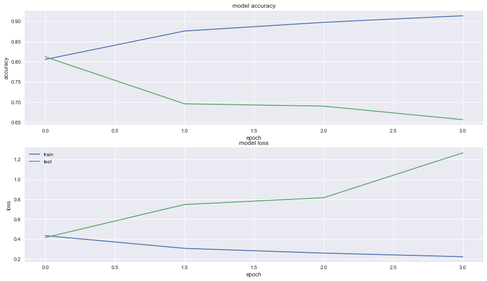

```python
plot_history(summary)
```

Clear signals of overfitting here.

Let's do a prediction anyway (on test data, they were not use for training!) and see what we get.

```python
# Prediction functions
def prediction_labels_dict(path):
    """Generates events ID list and their labels"""
    # read ids
    gamma_ids = glob.glob(path + '/gammas/*.npz')
    proton_ids = glob.glob(path + '/protons/*.npz')

    ids = gamma_ids + proton_ids
    # build ids dictionary
    id_dict = {'pred': ids}

    # make labels
    gamma_labels = [1 for _ in range(len(gamma_ids))]
    proton_labels = [0 for _ in range(len(proton_ids))]

    pred_labels = gamma_labels + proton_labels

    # build labels dictionary
    labels_dict = dict(zip(ids, pred_labels))

    return id_dict, labels_dict


def predict_gen(predict_path, last_act_layer='sigmoid'):
    def rmse(y_true, y_pred):
        return K.sqrt(K.mean(K.square(y_pred - y_true), axis=-1))

    params = {'width': 56,
              'height': 56,
              'batch_size': 20,
              'shuffle': True}

    epochs = 50
    nb_predict_samples = 10000

    model = conv_model(params['width'], params['height'], channels=1, batch_norm=True)

    model.add(Dense(1))
    model.add(BatchNormalization(axis=-1))
    model.add(Activation(last_act_layer))
    model.load_weights(last_act_layer + "_weights_matrix.best.hdf5")
    logger.info("Loaded weights from file")
    model.compile(loss='binary_crossentropy', optimizer='adam', metrics=['accuracy', rmse])

    logger.info("Created model")

    logger.info("Generating IDs and labels dictionaries...")
    # pdb.set_trace()
    partition, labels = prediction_labels_dict(predict_path)
    logger.info("Done.")

    predict_generator = DataGenerator(**params).generate(labels, partition['pred'])

    predictions = []
    true_labels = []

    start = time.process_time()

    logger.info("Now predict!")
    import pdb
    for i in range(nb_predict_samples):
        pg = next(predict_generator)
#         pdb.set_trace()
        img = pg[0]
        lab = pg[1]
        single_pred = model.predict_proba(img, params['batch_size'], verbose=0)
        predictions.append(single_pred)
        true_labels.append(lab)

    stop = time.process_time()
    logger.info("Time to predict: {}".format(stop - start))

    predictions = np.squeeze(np.stack(predictions))
    labels = np.squeeze(np.stack(true_labels).astype(np.uint8))

    np.savez_compressed(last_act_layer + '_keras_predictions_labels', predictions=predictions, labels=labels)


    return np.stack(predictions), np.stack(labels)
```

```python
predict_path = test_p

pred, true_labels = predict_gen(predict_path)
```

```
INFO:keras_reco:Loaded weights from file
INFO:keras_reco:Created model
INFO:keras_reco:Generating IDs and labels dictionaries...
INFO:keras_reco:Done.
INFO:keras_reco:Now predict!
INFO:keras_reco:Time to predict: 631.6797890000003
```

Now some code to analyze results

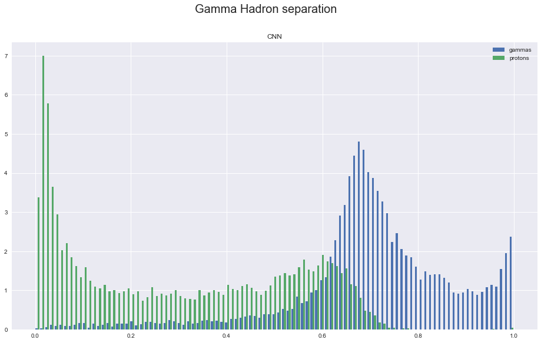

```python
%matplotlib inline
import matplotlib.pyplot as plt
import seaborn as sns
sns.set()

with np.load('sigmoid_keras_predictions_labels.npz') as data:
    dnn_prob = data['predictions']
    dnn_labels = data['labels']

dnn_gprob = dnn_prob[np.where(dnn_labels==1)]
dnn_pprob = dnn_prob[np.where(dnn_labels==0)]

f, ax1 = plt.subplots(figsize=(16, 9))
f.suptitle('Gamma Hadron separation', fontsize=20)

# b = np.linspace(0, 1, 100)

ax1.hist([dnn_gprob, dnn_pprob], bins=101, label=['gammas', 'protons'], normed=True)
ax1.set_title('CNN')
ax1.legend(loc='best')
```

Well.. **ugly results**.

## Use png images: hope to have better results

Reasons why results above are so bad are not clear: it could probably be the number of training inputs was too poor.. In order to explore other functionalities of `keras`, I'll do the same exercise with png images (as usual, generated from `lv1a` calibrated data.

To do this, I have to define different functions, using the already mentioned `ImageDataGenerator.flow_from_directory` magic function.

```python
def keras_dnn(train_path, validation_path, img_width, img_height, img_channels, last_act_layer='sigmoid', batch_norm=False):


    from keras.preprocessing.image import ImageDataGenerator
    from keras.callbacks import ModelCheckpoint, EarlyStopping
    from keras.layers import Activation, Dense, BatchNormalization
    from keras import backend as K

    # reproducibility
    np.random.seed(42)
    from tensorflow import set_random_seed
    set_random_seed(4242)

    nb_train_samples = 70000 * 2
    nb_validation_samples = 30000 * 2
    epochs = 30
    batch_size = 16

    model = conv_model(img_width, img_height, batch_norm=batch_norm, channels=img_channels)

    def rmse(y_true, y_pred):
        return K.sqrt(K.mean(K.square(y_pred - y_true), axis=-1))

    if K.image_data_format() == 'channels_first':
        norm_axis = 1
    else:
        norm_axis = -1

    # model.load_weights('first_try.h5')

    if last_act_layer == 'sigmoid':
        model.add(Dense(1))
        if batch_norm:
            model.add(BatchNormalization(axis=norm_axis))
        model.add(Activation(last_act_layer))
        model.compile(loss='binary_crossentropy', optimizer='adam', metrics=['accuracy', rmse])
    else:
        model.add(Dense(2))
        if batch_norm:
            model.add(BatchNormalization(axis=norm_axis))
        model.add(Activation(last_act_layer))
        model.compile(loss='sparse_categorical_crossentropy', optimizer='adam', metrics=['accuracy', rmse])

    train_datagen = ImageDataGenerator(rescale=1. / 255)

    test_datagen = ImageDataGenerator(rescale=1. / 255)

    train_generator = train_datagen.flow_from_directory(train_path,
                                                        target_size=(img_width, img_height),
                                                        batch_size=batch_size,
                                                        class_mode='binary',
                                                        color_mode='grayscale',
                                                        shuffle=True)

    validation_generator = test_datagen.flow_from_directory(validation_path,
                                                            target_size=(img_width, img_height),
                                                            batch_size=batch_size,
                                                            class_mode='binary',
                                                            color_mode='grayscale',
                                                            shuffle=True)

    filepath = last_act_layer + "_images_weights.best.hdf5"
    checkpoint = ModelCheckpoint(filepath, monitor='val_acc', verbose=1, save_best_only=True, mode='max')
    earlystopping = EarlyStopping(monitor='val_acc', patience=5, min_delta=0.001)
    callbacks_list = [checkpoint, earlystopping]

    start = time.process_time()
    summary = model.fit_generator(train_generator, steps_per_epoch=nb_train_samples // batch_size,
                                  epochs=epochs, validation_data=validation_generator,
                                  validation_steps=nb_validation_samples // batch_size,
                                  callbacks=callbacks_list)

    stop = time.process_time()
    logger.info("Time to fit the model: {}".format(stop - start))

    # model.save_weights('first_try.h5')

    return summary, train_generator.class_indices
```

```python
png_summary, ci = keras_dnn('/Users/francesco/WORK/ASTRI-CTA/Data/images/train/', '/Users/francesco/WORK/ASTRI-CTA/Data/images/test/', 56, 56, 1)
```

```
Found 140000 images belonging to 2 classes.
Found 60000 images belonging to 2 classes.

Epoch 00001: val_acc improved from -inf to 0.94340, saving model to sigmoid_images_weights.best.hdf5

Epoch 00002: val_acc improved from 0.94340 to 0.95120, saving model to sigmoid_images_weights.best.hdf5

Epoch 00003: val_acc improved from 0.95120 to 0.95277, saving model to sigmoid_images_weights.best.hdf5

Epoch 00004: val_acc improved from 0.95277 to 0.95670, saving model to sigmoid_images_weights.best.hdf5

Epoch 00005: val_acc did not improve from 0.95670

Epoch 00006: val_acc improved from 0.95670 to 0.95702, saving model to sigmoid_images_weights.best.hdf5

Epoch 00007: val_acc did not improve from 0.95702

Epoch 00008: val_acc improved from 0.95702 to 0.95707, saving model to sigmoid_images_weights.best.hdf5
```

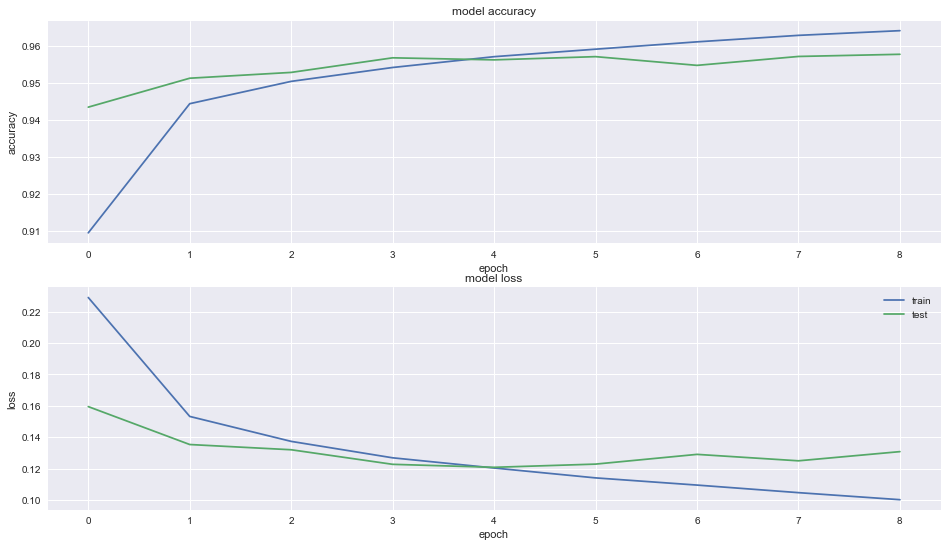

```python
plot_history(png_summary)
```

Quite better uh? **Why?**

[figure not shown]

Let's predict some data.

NB: you may notice that we save `predictions` with `1 - np.squeeze(np.stack(predictions))` at the end of the function: that is because it is `keras`'s `ImageDataGenerator.flow_from_directory` who assign the label, and it gives 0 to gammas, 1 to protons.

Don't believe me?

```python
# Look at this:
ci
```

```
{'gammas': 0, 'protons': 1}
```

There you are.

```python
def keras_predict_gen(predict_path, img_width, img_height, img_channels, last_act_layer='sigmoid', batch_norm=False):


    from keras.preprocessing.image import ImageDataGenerator
    from keras import backend as K
    from keras.layers import Activation, Dense, BatchNormalization

    nb_predict_samples = 200000 * 2
    batch_size = 1


    model = conv_model(img_width, img_height, batch_norm=batch_norm, channels=img_channels)

    # load weights
    # model.load_weights(last_act_layer + "_weights.best.hdf5")
    # logger.info("Loaded weights from file")

    def rmse(y_true, y_pred):
        return K.sqrt(K.mean(K.square(y_pred - y_true), axis=-1))

    if K.image_data_format() == 'channels_first':
        norm_axis = 1
    else:
        norm_axis = -1

    if last_act_layer == 'sigmoid':
        model.add(Dense(1))
        if batch_norm:
            model.add(BatchNormalization(axis=norm_axis))
        model.add(Activation(last_act_layer))
        model.load_weights(last_act_layer + "_images_weights.best.hdf5")
        logger.info("Loaded weights from file")
        model.compile(loss='binary_crossentropy', optimizer='adam', metrics=['accuracy', rmse])
    else:
        model.add(Dense(2))
        if batch_norm:
            model.add(BatchNormalization(axis=norm_axis))
        model.add(Activation(last_act_layer))
        model.load_weights(last_act_layer + "_weights.best.hdf5")
        logger.info("Loaded weights from file")
        model.compile(loss='sparse_categorical_crossentropy', optimizer='adam', metrics=['accuracy', rmse])

    logger.info("Created model")

    datagen = ImageDataGenerator(rescale=1. / 255)

    predict_generator = datagen.flow_from_directory(predict_path,
                                                    target_size=(img_width, img_height),
                                                    batch_size=batch_size,
                                                    class_mode='binary',
                                                    color_mode='grayscale',
                                                    shuffle=False)

    predictions = []
    labels = []

    start = time.process_time()

    # predictions = model.predict_generator(predict_generator, steps=nb_predict_samples // batch_size)
    for i in range(nb_predict_samples):
        pg = next(predict_generator)
        img = pg[0]
        lab = pg[1]
        single_pred = model.predict_proba(img, batch_size, verbose=0)
        predictions.append(single_pred)
        labels.append(lab)

    stop = time.process_time()
    logger.info("Time to predict: {}".format(stop - start))

    predictions = 1.0 - np.squeeze(np.stack(predictions))
    labels = np.squeeze(np.stack(labels).astype(np.uint8))

    np.savez_compressed(last_act_layer + '_keras_images_predictions_labels', predictions=predictions, labels=labels)


    return np.stack(predictions), np.stack(labels)
```

```python
predict_path = '/Users/francesco/WORK/ASTRI-CTA/Data/images/predict/'
pred, lab = keras_predict_gen(predict_path, 56, 56, 1)
```

```
INFO:keras_reco:Loaded weights from file
INFO:keras_reco:Created model
```

```
Found 400000 images belonging to 2 classes.
```

```
INFO:keras_reco:Time to predict: 1253.5589519999994
```

```python
pred.shape, lab.shape
```

```
((400000,), (400000,))
```

Ok, things seemed to work out fine, let's see the results

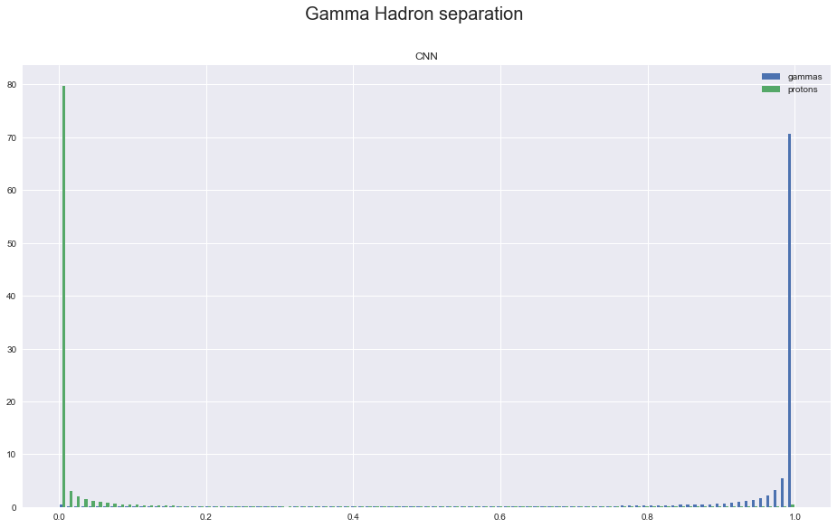

```python
%matplotlib inline
import matplotlib.pyplot as plt
import seaborn as sns
sns.set()

with np.load('sigmoid_keras_images_predictions_labels.npz') as data:
    dnn_prob = data['predictions']
    dnn_labels = data['labels']

dnn_gprob = dnn_prob[np.where(dnn_labels==0)]
dnn_pprob = dnn_prob[np.where(dnn_labels==1)]

f, ax1 = plt.subplots(figsize=(16, 9))
f.suptitle('Gamma Hadron separation', fontsize=20)

ax1.hist([dnn_gprob, dnn_pprob], bins=101, label=['gammas', 'protons'], normed=True)
ax1.set_title('CNN')
ax1.legend(loc='best')
```

MUCH BETTER!

The rest of the analysis can be an useful exercise, it can be done following the _DNN*gh.html* file under this same directory.